# Risk Factor Analysis

## Outcome Variable

**Outcome Variable:** y_rate_haz

## Predictor Variables

**Intervention Variable:** parity

**Adjustment Set:**

unadjusted

## Stratifying Variables

The analysis was stratified on these variable(s):

- agecat
- studyid
- country

## Data Summary

| agecat | studyid | country | parity | n_cell | n |
| --- | --- | --- | --- | --- | --- |
| 0-3 months | COHORTS | GUATEMALA | 1 | 93 | 728 |
| 0-3 months | COHORTS | GUATEMALA | 2 | 111 | 728 |
| 0-3 months | COHORTS | GUATEMALA | 3+ | 524 | 728 |
| 0-3 months | COHORTS | INDIA | 1 | 671 | 4021 |
| 0-3 months | COHORTS | INDIA | 2 | 1015 | 4021 |
| 0-3 months | COHORTS | INDIA | 3+ | 2335 | 4021 |
| 0-3 months | GMS-Nepal | NEPAL | 1 | 137 | 509 |
| 0-3 months | GMS-Nepal | NEPAL | 2 | 129 | 509 |
| 0-3 months | GMS-Nepal | NEPAL | 3+ | 243 | 509 |
| 0-3 months | JiVitA-3 | BANGLADESH | 1 | 6338 | 19878 |
| 0-3 months | JiVitA-3 | BANGLADESH | 2 | 6881 | 19878 |
| 0-3 months | JiVitA-3 | BANGLADESH | 3+ | 6659 | 19878 |
| 0-3 months | Keneba | GAMBIA | 1 | 130 | 1145 |
| 0-3 months | Keneba | GAMBIA | 2 | 113 | 1145 |
| 0-3 months | Keneba | GAMBIA | 3+ | 902 | 1145 |
| 0-3 months | PROVIDE | BANGLADESH | 1 | 242 | 640 |
| 0-3 months | PROVIDE | BANGLADESH | 2 | 226 | 640 |
| 0-3 months | PROVIDE | BANGLADESH | 3+ | 172 | 640 |
| 0-3 months | SAS-CompFeed | INDIA | 1 | 344 | 1261 |
| 0-3 months | SAS-CompFeed | INDIA | 2 | 298 | 1261 |
| 0-3 months | SAS-CompFeed | INDIA | 3+ | 619 | 1261 |
| 0-3 months | ZVITAMBO | ZIMBABWE | 1 | 3100 | 7981 |
| 0-3 months | ZVITAMBO | ZIMBABWE | 2 | 2478 | 7981 |
| 0-3 months | ZVITAMBO | ZIMBABWE | 3+ | 2403 | 7981 |
| 3-6 months | COHORTS | GUATEMALA | 1 | 107 | 805 |
| 3-6 months | COHORTS | GUATEMALA | 2 | 114 | 805 |
| 3-6 months | COHORTS | GUATEMALA | 3+ | 584 | 805 |
| 3-6 months | COHORTS | INDIA | 1 | 675 | 4069 |
| 3-6 months | COHORTS | INDIA | 2 | 1042 | 4069 |
| 3-6 months | COHORTS | INDIA | 3+ | 2352 | 4069 |

[output cut: 156 more lines]

The following strata were considered:

- agecat: 0-3 months, studyid: COHORTS, country: GUATEMALA
- agecat: 0-3 months, studyid: COHORTS, country: INDIA
- agecat: 0-3 months, studyid: GMS-Nepal, country: NEPAL
- agecat: 0-3 months, studyid: JiVitA-3, country: BANGLADESH
- agecat: 0-3 months, studyid: Keneba, country: GAMBIA
- agecat: 0-3 months, studyid: PROVIDE, country: BANGLADESH
- agecat: 0-3 months, studyid: SAS-CompFeed, country: INDIA
- agecat: 0-3 months, studyid: ZVITAMBO, country: ZIMBABWE
- agecat: 12-15 months, studyid: COHORTS, country: GUATEMALA
- agecat: 12-15 months, studyid: GMS-Nepal, country: NEPAL
- agecat: 12-15 months, studyid: Keneba, country: GAMBIA
- agecat: 12-15 months, studyid: PROVIDE, country: BANGLADESH
- agecat: 12-15 months, studyid: SAS-CompFeed, country: INDIA
- agecat: 12-15 months, studyid: SAS-FoodSuppl, country: INDIA
- agecat: 12-15 months, studyid: TanzaniaChild2, country: TANZANIA, UNITED REPUBLIC OF
- agecat: 12-15 months, studyid: ZVITAMBO, country: ZIMBABWE
- agecat: 15-18 months, studyid: COHORTS, country: GUATEMALA
- agecat: 15-18 months, studyid: GMS-Nepal, country: NEPAL
- agecat: 15-18 months, studyid: Keneba, country: GAMBIA
- agecat: 15-18 months, studyid: PROVIDE, country: BANGLADESH
- agecat: 15-18 months, studyid: SAS-CompFeed, country: INDIA
- agecat: 15-18 months, studyid: SAS-FoodSuppl, country: INDIA
- agecat: 15-18 months, studyid: TanzaniaChild2, country: TANZANIA, UNITED REPUBLIC OF
- agecat: 15-18 months, studyid: ZVITAMBO, country: ZIMBABWE
- agecat: 18-21 months, studyid: COHORTS, country: GUATEMALA
- agecat: 18-21 months, studyid: GMS-Nepal, country: NEPAL
- agecat: 18-21 months, studyid: Keneba, country: GAMBIA
- agecat: 18-21 months, studyid: PROVIDE, country: BANGLADESH
- agecat: 18-21 months, studyid: TanzaniaChild2, country: TANZANIA, UNITED REPUBLIC OF
- agecat: 18-21 months, studyid: ZVITAMBO, country: ZIMBABWE
- agecat: 21-24 months, studyid: COHORTS, country: GUATEMALA
- agecat: 21-24 months, studyid: GMS-Nepal, country: NEPAL
- agecat: 21-24 months, studyid: Keneba, country: GAMBIA
- agecat: 21-24 months, studyid: PROVIDE, country: BANGLADESH
- agecat: 21-24 months, studyid: ZVITAMBO, country: ZIMBABWE
- agecat: 3-6 months, studyid: COHORTS, country: GUATEMALA
- agecat: 3-6 months, studyid: COHORTS, country: INDIA
- agecat: 3-6 months, studyid: GMS-Nepal, country: NEPAL
- agecat: 3-6 months, studyid: JiVitA-3, country: BANGLADESH
- agecat: 3-6 months, studyid: Keneba, country: GAMBIA
- agecat: 3-6 months, studyid: PROVIDE, country: BANGLADESH
- agecat: 3-6 months, studyid: SAS-CompFeed, country: INDIA
- agecat: 3-6 months, studyid: TanzaniaChild2, country: TANZANIA, UNITED REPUBLIC OF
- agecat: 3-6 months, studyid: ZVITAMBO, country: ZIMBABWE
- agecat: 6-9 months, studyid: COHORTS, country: GUATEMALA
- agecat: 6-9 months, studyid: COHORTS, country: INDIA
- agecat: 6-9 months, studyid: GMS-Nepal, country: NEPAL
- agecat: 6-9 months, studyid: Keneba, country: GAMBIA
- agecat: 6-9 months, studyid: PROVIDE, country: BANGLADESH
- agecat: 6-9 months, studyid: SAS-CompFeed, country: INDIA
- agecat: 6-9 months, studyid: SAS-FoodSuppl, country: INDIA
- agecat: 6-9 months, studyid: TanzaniaChild2, country: TANZANIA, UNITED REPUBLIC OF
- agecat: 6-9 months, studyid: ZVITAMBO, country: ZIMBABWE
- agecat: 9-12 months, studyid: COHORTS, country: GUATEMALA
- agecat: 9-12 months, studyid: COHORTS, country: INDIA
- agecat: 9-12 months, studyid: GMS-Nepal, country: NEPAL
- agecat: 9-12 months, studyid: Keneba, country: GAMBIA
- agecat: 9-12 months, studyid: PROVIDE, country: BANGLADESH
- agecat: 9-12 months, studyid: SAS-CompFeed, country: INDIA
- agecat: 9-12 months, studyid: SAS-FoodSuppl, country: INDIA
- agecat: 9-12 months, studyid: TanzaniaChild2, country: TANZANIA, UNITED REPUBLIC OF
- agecat: 9-12 months, studyid: ZVITAMBO, country: ZIMBABWE

### Dropped Strata

Some strata were dropped due to rare outcomes:

- agecat: 6-9 months, studyid: SAS-FoodSuppl, country: INDIA
- agecat: 9-12 months, studyid: SAS-FoodSuppl, country: INDIA
- agecat: 12-15 months, studyid: SAS-FoodSuppl, country: INDIA
- agecat: 15-18 months, studyid: SAS-FoodSuppl, country: INDIA
- agecat: 18-21 months, studyid: TanzaniaChild2, country: TANZANIA, UNITED REPUBLIC OF

## Methods Detail

We’re interested in the causal parameters $E[Y_a]$ for all values of $a \in \mathcal{A}$. These parameters represent the mean outcome if, possibly contrary to fact, we intervened to set all units to have $A=a$. Under the randomization and positivity assumptions, these are identified by the statistical parameters $\psi_a=E_W[E_{Y|A,W}(Y|A=a,W)]$. In addition, we’re interested in the mean of $Y$, $E[Y]$ under no intervention (the observed mean). We will estimate these parameters by using SuperLearner to fit the relevant likelihood factors – $E_{Y|A,W}(Y|A=a,W)$ and $p(A=a|W)$, and then updating our likelihood fit using a joint TMLE.

For unadjusted analyses ($W=\{\}$), initial likelihoods were estimated using Lrnr_glm to estimate the simple $E(Y|A)$ and Lrnr_mean to estimate $p(A)$. For adjusted analyses, a small library containing Lrnr_glmnet, Lrnr_xgboost, and Lrnr_mean was used.

Having estimated these parameters, we will then use the delta method to estimate relative risks and attributable risks relative to a prespecified baseline level of $A$.

# Results Detail

## Results Plots

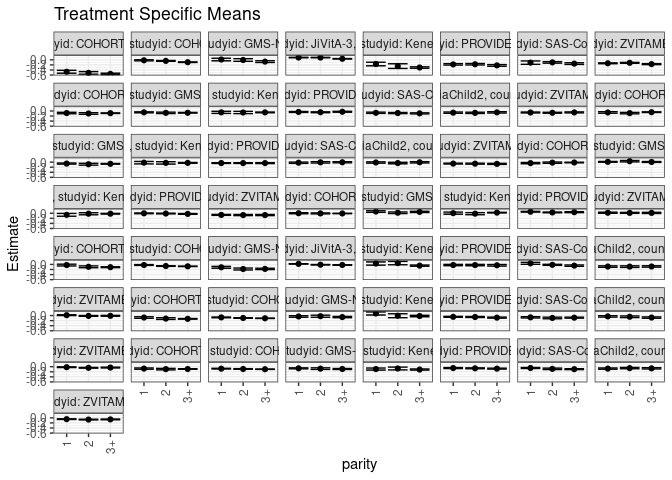

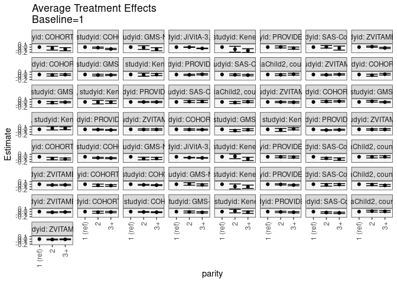

[figure not shown]

## Results Table

### Parameter: TSM

| agecat | studyid | country | intervention_level | baseline_level | estimate | ci_lower | ci_upper |
| --- | --- | --- | --- | --- | --- | --- | --- |
| 0-3 months | COHORTS | GUATEMALA | 1 | NA | -0.4708187 | -0.5271043 | -0.4145331 |
| 0-3 months | COHORTS | GUATEMALA | 2 | NA | -0.5148867 | -0.5657468 | -0.4640266 |
| 0-3 months | COHORTS | GUATEMALA | 3+ | NA | -0.5536971 | -0.5799525 | -0.5274417 |
| 0-3 months | COHORTS | INDIA | 1 | NA | -0.0187050 | -0.0384547 | 0.0010446 |
| 0-3 months | COHORTS | INDIA | 2 | NA | -0.0416906 | -0.0579024 | -0.0254789 |
| 0-3 months | COHORTS | INDIA | 3+ | NA | -0.0931318 | -0.1052278 | -0.0810358 |
| 0-3 months | GMS-Nepal | NEPAL | 1 | NA | 0.0129675 | -0.0380334 | 0.0639683 |
| 0-3 months | GMS-Nepal | NEPAL | 2 | NA | -0.0063699 | -0.0577080 | 0.0449682 |
| 0-3 months | GMS-Nepal | NEPAL | 3+ | NA | -0.0704722 | -0.1046181 | -0.0363263 |
| 0-3 months | JiVitA-3 | BANGLADESH | 1 | NA | 0.0912783 | 0.0833430 | 0.0992136 |
| 0-3 months | JiVitA-3 | BANGLADESH | 2 | NA | 0.0896289 | 0.0822339 | 0.0970240 |
| 0-3 months | JiVitA-3 | BANGLADESH | 3+ | NA | 0.0415708 | 0.0340508 | 0.0490907 |
| 0-3 months | Keneba | GAMBIA | 1 | NA | -0.1645456 | -0.2349040 | -0.0941872 |
| 0-3 months | Keneba | GAMBIA | 2 | NA | -0.2476390 | -0.3395852 | -0.1556929 |
| 0-3 months | Keneba | GAMBIA | 3+ | NA | -0.3033631 | -0.3312523 | -0.2754739 |
| 0-3 months | PROVIDE | BANGLADESH | 1 | NA | -0.1793779 | -0.2082979 | -0.1504580 |
| 0-3 months | PROVIDE | BANGLADESH | 2 | NA | -0.1739360 | -0.2027779 | -0.1450941 |
| 0-3 months | PROVIDE | BANGLADESH | 3+ | NA | -0.2187601 | -0.2512693 | -0.1862508 |
| 0-3 months | SAS-CompFeed | INDIA | 1 | NA | -0.1105817 | -0.1765335 | -0.0446299 |
| 0-3 months | SAS-CompFeed | INDIA | 2 | NA | -0.1004472 | -0.1301613 | -0.0707330 |
| 0-3 months | SAS-CompFeed | INDIA | 3+ | NA | -0.1496339 | -0.1820546 | -0.1172131 |
| 0-3 months | ZVITAMBO | ZIMBABWE | 1 | NA | -0.1360342 | -0.1525538 | -0.1195146 |
| 0-3 months | ZVITAMBO | ZIMBABWE | 2 | NA | -0.1179753 | -0.1358640 | -0.1000867 |
| 0-3 months | ZVITAMBO | ZIMBABWE | 3+ | NA | -0.1687210 | -0.1876347 | -0.1498072 |
| 3-6 months | COHORTS | GUATEMALA | 1 | NA | -0.0249886 | -0.0606237 | 0.0106465 |
| 3-6 months | COHORTS | GUATEMALA | 2 | NA | -0.0944722 | -0.1296888 | -0.0592555 |
| 3-6 months | COHORTS | GUATEMALA | 3+ | NA | -0.1097751 | -0.1273667 | -0.0921836 |
| 3-6 months | COHORTS | INDIA | 1 | NA | -0.0231333 | -0.0397339 | -0.0065328 |
| 3-6 months | COHORTS | INDIA | 2 | NA | -0.0628806 | -0.0758717 | -0.0498894 |
| 3-6 months | COHORTS | INDIA | 3+ | NA | -0.0751407 | -0.0844771 | -0.0658043 |

[output cut: 141 more lines]

### Parameter: E(Y)

| agecat | studyid | country | intervention_level | baseline_level | estimate | ci_lower | ci_upper |
| --- | --- | --- | --- | --- | --- | --- | --- |
| 0-3 months | COHORTS | GUATEMALA | NA | NA | -0.5371921 | -0.5589495 | -0.5154346 |
| 0-3 months | COHORTS | INDIA | NA | NA | -0.0677269 | -0.0765502 | -0.0589035 |
| 0-3 months | GMS-Nepal | NEPAL | NA | NA | -0.0317680 | -0.0569509 | -0.0065852 |
| 0-3 months | JiVitA-3 | BANGLADESH | NA | NA | 0.0740557 | 0.0691191 | 0.0789922 |
| 0-3 months | Keneba | GAMBIA | NA | NA | -0.2821028 | -0.3073160 | -0.2568895 |
| 0-3 months | PROVIDE | BANGLADESH | NA | NA | -0.1880402 | -0.2054115 | -0.1706689 |
| 0-3 months | SAS-CompFeed | INDIA | NA | NA | -0.1273566 | -0.1543372 | -0.1003761 |
| 0-3 months | ZVITAMBO | ZIMBABWE | NA | NA | -0.1402688 | -0.1504985 | -0.1300391 |
| 3-6 months | COHORTS | GUATEMALA | NA | NA | -0.0963382 | -0.1109683 | -0.0817082 |
| 3-6 months | COHORTS | INDIA | NA | NA | -0.0633737 | -0.0703095 | -0.0564379 |
| 3-6 months | GMS-Nepal | NEPAL | NA | NA | -0.1613977 | -0.1800128 | -0.1427826 |
| 3-6 months | JiVitA-3 | BANGLADESH | NA | NA | -0.0034426 | -0.0083086 | 0.0014234 |
| 3-6 months | Keneba | GAMBIA | NA | NA | -0.0278645 | -0.0482582 | -0.0074707 |
| 3-6 months | PROVIDE | BANGLADESH | NA | NA | -0.0269625 | -0.0428628 | -0.0110622 |
| 3-6 months | SAS-CompFeed | INDIA | NA | NA | -0.0166348 | -0.0360336 | 0.0027639 |
| 3-6 months | TanzaniaChild2 | TANZANIA, UNITED REPUBLIC OF | NA | NA | -0.0841486 | -0.1008599 | -0.0674373 |
| 3-6 months | ZVITAMBO | ZIMBABWE | NA | NA | -0.0012924 | -0.0104920 | 0.0079073 |
| 6-9 months | COHORTS | GUATEMALA | NA | NA | -0.1207546 | -0.1326448 | -0.1088643 |
| 6-9 months | COHORTS | INDIA | NA | NA | -0.0985796 | -0.1048064 | -0.0923527 |
| 6-9 months | GMS-Nepal | NEPAL | NA | NA | -0.0438931 | -0.0614010 | -0.0263853 |
| 6-9 months | Keneba | GAMBIA | NA | NA | -0.0045762 | -0.0287122 | 0.0195598 |
| 6-9 months | PROVIDE | BANGLADESH | NA | NA | -0.0614264 | -0.0722690 | -0.0505838 |
| 6-9 months | SAS-CompFeed | INDIA | NA | NA | -0.0823482 | -0.0898643 | -0.0748321 |
| 6-9 months | TanzaniaChild2 | TANZANIA, UNITED REPUBLIC OF | NA | NA | -0.0525285 | -0.0687206 | -0.0363364 |
| 6-9 months | ZVITAMBO | ZIMBABWE | NA | NA | -0.0315646 | -0.0399465 | -0.0231828 |
| 9-12 months | COHORTS | GUATEMALA | NA | NA | -0.0887143 | -0.0986894 | -0.0787393 |
| 9-12 months | COHORTS | INDIA | NA | NA | -0.0933036 | -0.0995020 | -0.0871051 |
| 9-12 months | GMS-Nepal | NEPAL | NA | NA | -0.0798239 | -0.0934194 | -0.0662284 |
| 9-12 months | Keneba | GAMBIA | NA | NA | -0.1061496 | -0.1248815 | -0.0874176 |
| 9-12 months | PROVIDE | BANGLADESH | NA | NA | -0.0630470 | -0.0740183 | -0.0520757 |
| 9-12 months | SAS-CompFeed | INDIA | NA | NA | -0.0811963 | -0.0946758 | -0.0677169 |
| 9-12 months | TanzaniaChild2 | TANZANIA, UNITED REPUBLIC OF | NA | NA | -0.0652640 | -0.0796167 | -0.0509113 |
| 9-12 months | ZVITAMBO | ZIMBABWE | NA | NA | -0.0590759 | -0.0665312 | -0.0516205 |
| 12-15 months | COHORTS | GUATEMALA | NA | NA | -0.0875200 | -0.0977014 | -0.0773386 |
| 12-15 months | GMS-Nepal | NEPAL | NA | NA | -0.0667249 | -0.0775841 | -0.0558657 |
| 12-15 months | Keneba | GAMBIA | NA | NA | -0.0554331 | -0.0683830 | -0.0424832 |
| 12-15 months | PROVIDE | BANGLADESH | NA | NA | -0.0409107 | -0.0510053 | -0.0308161 |
| 12-15 months | SAS-CompFeed | INDIA | NA | NA | -0.0847390 | -0.0988912 | -0.0705868 |
| 12-15 months | TanzaniaChild2 | TANZANIA, UNITED REPUBLIC OF | NA | NA | -0.0649105 | -0.0794330 | -0.0503881 |
| 12-15 months | ZVITAMBO | ZIMBABWE | NA | NA | -0.0622748 | -0.0728257 | -0.0517239 |
| 15-18 months | COHORTS | GUATEMALA | NA | NA | -0.0545580 | -0.0655035 | -0.0436124 |
| 15-18 months | GMS-Nepal | NEPAL | NA | NA | -0.0689576 | -0.0815283 | -0.0563869 |
| 15-18 months | Keneba | GAMBIA | NA | NA | -0.0289062 | -0.0415733 | -0.0162391 |
| 15-18 months | PROVIDE | BANGLADESH | NA | NA | -0.0376437 | -0.0463882 | -0.0288992 |
| 15-18 months | SAS-CompFeed | INDIA | NA | NA | -0.0117156 | -0.0214328 | -0.0019983 |
| 15-18 months | TanzaniaChild2 | TANZANIA, UNITED REPUBLIC OF | NA | NA | -0.0189489 | -0.0345324 | -0.0033654 |
| 15-18 months | ZVITAMBO | ZIMBABWE | NA | NA | -0.0623481 | -0.0733140 | -0.0513822 |
| 18-21 months | COHORTS | GUATEMALA | NA | NA | -0.0194829 | -0.0293542 | -0.0096117 |
| 18-21 months | GMS-Nepal | NEPAL | NA | NA | 0.0155926 | 0.0038526 | 0.0273327 |
| 18-21 months | Keneba | GAMBIA | NA | NA | -0.0220748 | -0.0349179 | -0.0092317 |
| 18-21 months | PROVIDE | BANGLADESH | NA | NA | -0.0109399 | -0.0190984 | -0.0027814 |
| 18-21 months | ZVITAMBO | ZIMBABWE | NA | NA | -0.0689095 | -0.0806852 | -0.0571338 |
| 21-24 months | COHORTS | GUATEMALA | NA | NA | -0.0058090 | -0.0136683 | 0.0020502 |
| 21-24 months | GMS-Nepal | NEPAL | NA | NA | 0.0481269 | 0.0325947 | 0.0636591 |
| 21-24 months | Keneba | GAMBIA | NA | NA | 0.0194181 | 0.0072915 | 0.0315446 |
| 21-24 months | PROVIDE | BANGLADESH | NA | NA | 0.0462342 | 0.0375872 | 0.0548812 |
| 21-24 months | ZVITAMBO | ZIMBABWE | NA | NA | 0.0172279 | 0.0047469 | 0.0297089 |

### Parameter: ATE

| agecat | studyid | country | intervention_level | baseline_level | estimate | ci_lower | ci_upper |
| --- | --- | --- | --- | --- | --- | --- | --- |
| 0-3 months | COHORTS | GUATEMALA | 1 | 1 | 0.0000000 | 0.0000000 | 0.0000000 |
| 0-3 months | COHORTS | GUATEMALA | 2 | 1 | -0.0440680 | -0.1199285 | 0.0317925 |
| 0-3 months | COHORTS | GUATEMALA | 3+ | 1 | -0.0828784 | -0.1449865 | -0.0207703 |
| 0-3 months | COHORTS | INDIA | 1 | 1 | 0.0000000 | 0.0000000 | 0.0000000 |
| 0-3 months | COHORTS | INDIA | 2 | 1 | -0.0229856 | -0.0485369 | 0.0025657 |
| 0-3 months | COHORTS | INDIA | 3+ | 1 | -0.0744268 | -0.0975862 | -0.0512673 |
| 0-3 months | GMS-Nepal | NEPAL | 1 | 1 | 0.0000000 | 0.0000000 | 0.0000000 |
| 0-3 months | GMS-Nepal | NEPAL | 2 | 1 | -0.0193374 | -0.0917023 | 0.0530276 |
| 0-3 months | GMS-Nepal | NEPAL | 3+ | 1 | -0.0834397 | -0.1448157 | -0.0220636 |
| 0-3 months | JiVitA-3 | BANGLADESH | 1 | 1 | 0.0000000 | 0.0000000 | 0.0000000 |
| 0-3 months | JiVitA-3 | BANGLADESH | 2 | 1 | -0.0016493 | -0.0117181 | 0.0084194 |
| 0-3 months | JiVitA-3 | BANGLADESH | 3+ | 1 | -0.0497075 | -0.0601660 | -0.0392490 |
| 0-3 months | Keneba | GAMBIA | 1 | 1 | 0.0000000 | 0.0000000 | 0.0000000 |
| 0-3 months | Keneba | GAMBIA | 2 | 1 | -0.0830934 | -0.1988708 | 0.0326839 |
| 0-3 months | Keneba | GAMBIA | 3+ | 1 | -0.1388175 | -0.2145018 | -0.0631332 |
| 0-3 months | PROVIDE | BANGLADESH | 1 | 1 | 0.0000000 | 0.0000000 | 0.0000000 |
| 0-3 months | PROVIDE | BANGLADESH | 2 | 1 | 0.0054419 | -0.0354019 | 0.0462858 |
| 0-3 months | PROVIDE | BANGLADESH | 3+ | 1 | -0.0393821 | -0.0828932 | 0.0041290 |
| 0-3 months | SAS-CompFeed | INDIA | 1 | 1 | 0.0000000 | 0.0000000 | 0.0000000 |
| 0-3 months | SAS-CompFeed | INDIA | 2 | 1 | 0.0101345 | -0.0400569 | 0.0603259 |
| 0-3 months | SAS-CompFeed | INDIA | 3+ | 1 | -0.0390522 | -0.1192904 | 0.0411859 |
| 0-3 months | ZVITAMBO | ZIMBABWE | 1 | 1 | 0.0000000 | 0.0000000 | 0.0000000 |
| 0-3 months | ZVITAMBO | ZIMBABWE | 2 | 1 | 0.0180588 | -0.0062907 | 0.0424084 |
| 0-3 months | ZVITAMBO | ZIMBABWE | 3+ | 1 | -0.0326868 | -0.0577991 | -0.0075745 |
| 3-6 months | COHORTS | GUATEMALA | 1 | 1 | 0.0000000 | 0.0000000 | 0.0000000 |
| 3-6 months | COHORTS | GUATEMALA | 2 | 1 | -0.0694835 | -0.1195841 | -0.0193829 |
| 3-6 months | COHORTS | GUATEMALA | 3+ | 1 | -0.0847865 | -0.1245272 | -0.0450458 |
| 3-6 months | COHORTS | INDIA | 1 | 1 | 0.0000000 | 0.0000000 | 0.0000000 |
| 3-6 months | COHORTS | INDIA | 2 | 1 | -0.0397472 | -0.0608268 | -0.0186676 |
| 3-6 months | COHORTS | INDIA | 3+ | 1 | -0.0520074 | -0.0710533 | -0.0329614 |

[output cut: 141 more lines]

### Parameter: PAR

| agecat | studyid | country | intervention_level | baseline_level | estimate | ci_lower | ci_upper |
| --- | --- | --- | --- | --- | --- | --- | --- |
| 0-3 months | COHORTS | GUATEMALA | 1 | NA | -0.0663734 | -0.1195902 | -0.0131566 |
| 0-3 months | COHORTS | INDIA | 1 | NA | -0.0490219 | -0.0673991 | -0.0306446 |
| 0-3 months | GMS-Nepal | NEPAL | 1 | NA | -0.0447355 | -0.0875732 | -0.0018978 |
| 0-3 months | JiVitA-3 | BANGLADESH | 1 | NA | -0.0172226 | -0.0233509 | -0.0110944 |
| 0-3 months | Keneba | GAMBIA | 1 | NA | -0.1175572 | -0.1843548 | -0.0507595 |
| 0-3 months | PROVIDE | BANGLADESH | 1 | NA | -0.0086623 | -0.0311484 | 0.0138239 |
| 0-3 months | SAS-CompFeed | INDIA | 1 | NA | -0.0167750 | -0.0667428 | 0.0331928 |
| 0-3 months | ZVITAMBO | ZIMBABWE | 1 | NA | -0.0042346 | -0.0171011 | 0.0086318 |
| 3-6 months | COHORTS | GUATEMALA | 1 | NA | -0.0713496 | -0.1052070 | -0.0374923 |
| 3-6 months | COHORTS | INDIA | 1 | NA | -0.0402403 | -0.0554802 | -0.0250005 |
| 3-6 months | GMS-Nepal | NEPAL | 1 | NA | -0.0477317 | -0.0787974 | -0.0166660 |
| 3-6 months | JiVitA-3 | BANGLADESH | 1 | NA | -0.0244483 | -0.0306054 | -0.0182911 |
| 3-6 months | Keneba | GAMBIA | 1 | NA | -0.0629341 | -0.1208845 | -0.0049837 |
| 3-6 months | PROVIDE | BANGLADESH | 1 | NA | -0.0031256 | -0.0241217 | 0.0178704 |
| 3-6 months | SAS-CompFeed | INDIA | 1 | NA | -0.0592392 | -0.0928229 | -0.0256555 |
| 3-6 months | TanzaniaChild2 | TANZANIA, UNITED REPUBLIC OF | 1 | NA | -0.0003072 | -0.0233690 | 0.0227545 |
| 3-6 months | ZVITAMBO | ZIMBABWE | 1 | NA | -0.0170997 | -0.0290404 | -0.0051589 |
| 6-9 months | COHORTS | GUATEMALA | 1 | NA | -0.0430554 | -0.0718950 | -0.0142158 |
| 6-9 months | COHORTS | INDIA | 1 | NA | -0.0263524 | -0.0398731 | -0.0128317 |
| 6-9 months | GMS-Nepal | NEPAL | 1 | NA | -0.0087436 | -0.0357699 | 0.0182827 |
| 6-9 months | Keneba | GAMBIA | 1 | NA | -0.0871169 | -0.1446906 | -0.0295432 |
| 6-9 months | PROVIDE | BANGLADESH | 1 | NA | -0.0111583 | -0.0252021 | 0.0028855 |
| 6-9 months | SAS-CompFeed | INDIA | 1 | NA | -0.0124045 | -0.0386750 | 0.0138660 |
| 6-9 months | TanzaniaChild2 | TANZANIA, UNITED REPUBLIC OF | 1 | NA | -0.0196166 | -0.0414875 | 0.0022544 |
| 6-9 months | ZVITAMBO | ZIMBABWE | 1 | NA | -0.0117837 | -0.0224562 | -0.0011111 |
| 9-12 months | COHORTS | GUATEMALA | 1 | NA | -0.0144289 | -0.0377332 | 0.0088754 |
| 9-12 months | COHORTS | INDIA | 1 | NA | -0.0156041 | -0.0288421 | -0.0023660 |
| 9-12 months | GMS-Nepal | NEPAL | 1 | NA | -0.0157799 | -0.0354914 | 0.0039315 |
| 9-12 months | Keneba | GAMBIA | 1 | NA | -0.0139110 | -0.0541488 | 0.0263267 |
| 9-12 months | PROVIDE | BANGLADESH | 1 | NA | -0.0100157 | -0.0246904 | 0.0046591 |
| 9-12 months | SAS-CompFeed | INDIA | 1 | NA | -0.0306577 | -0.0484681 | -0.0128473 |
| 9-12 months | TanzaniaChild2 | TANZANIA, UNITED REPUBLIC OF | 1 | NA | 0.0094837 | -0.0098448 | 0.0288122 |
| 9-12 months | ZVITAMBO | ZIMBABWE | 1 | NA | -0.0080743 | -0.0174486 | 0.0013000 |
| 12-15 months | COHORTS | GUATEMALA | 1 | NA | -0.0062724 | -0.0319054 | 0.0193605 |
| 12-15 months | GMS-Nepal | NEPAL | 1 | NA | -0.0135636 | -0.0304420 | 0.0033149 |
| 12-15 months | Keneba | GAMBIA | 1 | NA | -0.0017011 | -0.0413015 | 0.0378993 |
| 12-15 months | PROVIDE | BANGLADESH | 1 | NA | -0.0019761 | -0.0151557 | 0.0112034 |
| 12-15 months | SAS-CompFeed | INDIA | 1 | NA | -0.0132512 | -0.0329219 | 0.0064195 |
| 12-15 months | TanzaniaChild2 | TANZANIA, UNITED REPUBLIC OF | 1 | NA | 0.0010192 | -0.0191071 | 0.0211454 |
| 12-15 months | ZVITAMBO | ZIMBABWE | 1 | NA | -0.0019467 | -0.0157783 | 0.0118849 |
| 15-18 months | COHORTS | GUATEMALA | 1 | NA | 0.0045263 | -0.0225832 | 0.0316357 |
| 15-18 months | GMS-Nepal | NEPAL | 1 | NA | -0.0115583 | -0.0302384 | 0.0071218 |
| 15-18 months | Keneba | GAMBIA | 1 | NA | -0.0078298 | -0.0538099 | 0.0381503 |
| 15-18 months | PROVIDE | BANGLADESH | 1 | NA | -0.0006724 | -0.0121798 | 0.0108349 |
| 15-18 months | SAS-CompFeed | INDIA | 1 | NA | 0.0116354 | -0.0152832 | 0.0385540 |
| 15-18 months | TanzaniaChild2 | TANZANIA, UNITED REPUBLIC OF | 1 | NA | -0.0049124 | -0.0264133 | 0.0165885 |
| 15-18 months | ZVITAMBO | ZIMBABWE | 1 | NA | -0.0048328 | -0.0185464 | 0.0088808 |
| 18-21 months | COHORTS | GUATEMALA | 1 | NA | 0.0197913 | -0.0030454 | 0.0426280 |
| 18-21 months | GMS-Nepal | NEPAL | 1 | NA | 0.0040965 | -0.0117875 | 0.0199805 |
| 18-21 months | Keneba | GAMBIA | 1 | NA | 0.0392064 | -0.0118735 | 0.0902864 |
| 18-21 months | PROVIDE | BANGLADESH | 1 | NA | -0.0093817 | -0.0202124 | 0.0014490 |
| 18-21 months | ZVITAMBO | ZIMBABWE | 1 | NA | -0.0039363 | -0.0191937 | 0.0113211 |
| 21-24 months | COHORTS | GUATEMALA | 1 | NA | -0.0077539 | -0.0261240 | 0.0106163 |
| 21-24 months | GMS-Nepal | NEPAL | 1 | NA | -0.0201723 | -0.0464891 | 0.0061445 |
| 21-24 months | Keneba | GAMBIA | 1 | NA | 0.0142711 | -0.0249008 | 0.0534430 |
| 21-24 months | PROVIDE | BANGLADESH | 1 | NA | -0.0143025 | -0.0256925 | -0.0029125 |
| 21-24 months | ZVITAMBO | ZIMBABWE | 1 | NA | -0.0034178 | -0.0201892 | 0.0133535 |